# Road Accidents in BMR

2022 · Executive Summary

Murat Kaya

## Contents

1. Research question, study area and data
2. Data preparation and analytical approach
3. Annual, second-order and monthly findings
4. Integrated evidence and limitations
5. Public-safety implications

## Research questions

**Where and when are recorded accidents concentrated in BMR?**

- How does recorded accident intensity vary across the region in 2022?
- Does the pattern show clustering or regularity relative to complete spatial randomness?
- Do concentrations remain in similar locations between months?

The purpose is to identify areas for closer road-safety investigation.

## Study area and data

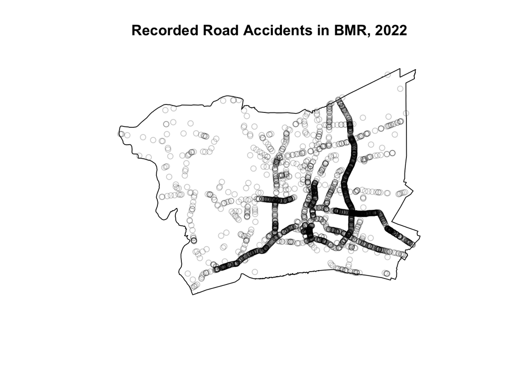

**Bangkok Metropolitan Region**

Bangkok, Nonthaburi, Pathum Thani, Samut Prakan, Samut Sakhon and Nakhon Pathom.

**Period:** 1 January to 31 December 2022.

**Reported BMR observations:** 3,599 accidents in the monthly analysis.

[Kaggle accident records](https://www.kaggle.com/datasets/thaweewatboy/thailand-road-accident-2019-2022) and [HDX / geoBoundaries ADM1 boundaries](https://data.humdata.org/dataset/geoboundaries-admin-boundaries-for-thailand).

Accessed 24 September 2026.

## Data preparation

- Remove exact duplicate rows and exclude records outside 2022.
- Remove records with missing, non-finite or out-of-range coordinates.
- Retain separate accidents at the same coordinates.
- Convert WGS 84 points and boundaries to UTM Zone 47N.
- Retain points inside the BMR observation window and rescale spatial distances to kilometres.

Coordinates are assumed to represent accident locations adequately. The incident date defines the study period.

## Analytical approach

| Analysis | Question answered | Main choices |
| --- | --- | --- |
| Annual KDE | Where are accidents concentrated? | Gaussian kernel, Diggle bandwidth and edge correction |
| Sampled L-function | Does the pattern depart from CSR? | Up to 1,000 accidents, 28 simulations and Ripley correction |
| Spatio-temporal KDE | Do concentrations change between months? | Incident month and a shared colour scale |

**CSR reference:** independent events with uniform intensity throughout the study window.

The L-function envelope is pointwise. Roads and traffic are unevenly distributed, limiting the suitability of the uniform reference.

## Annual accident intensity

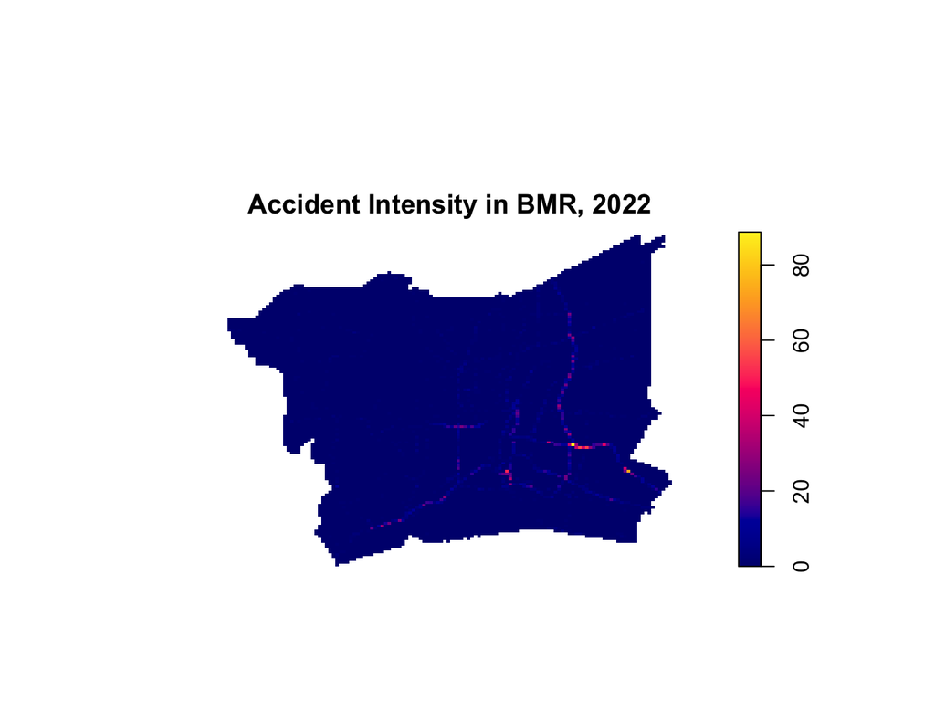

The report identifies:

- Higher intensity along a short southeastern corridor.
- Additional central and southern concentrations.
- Lower intensity across much of the west and north.

The reported 23 m bandwidth is much smaller than the approximately 979 × 737 m pixels. Local details and peak values are unreliable.

## Clustering relative to CSR

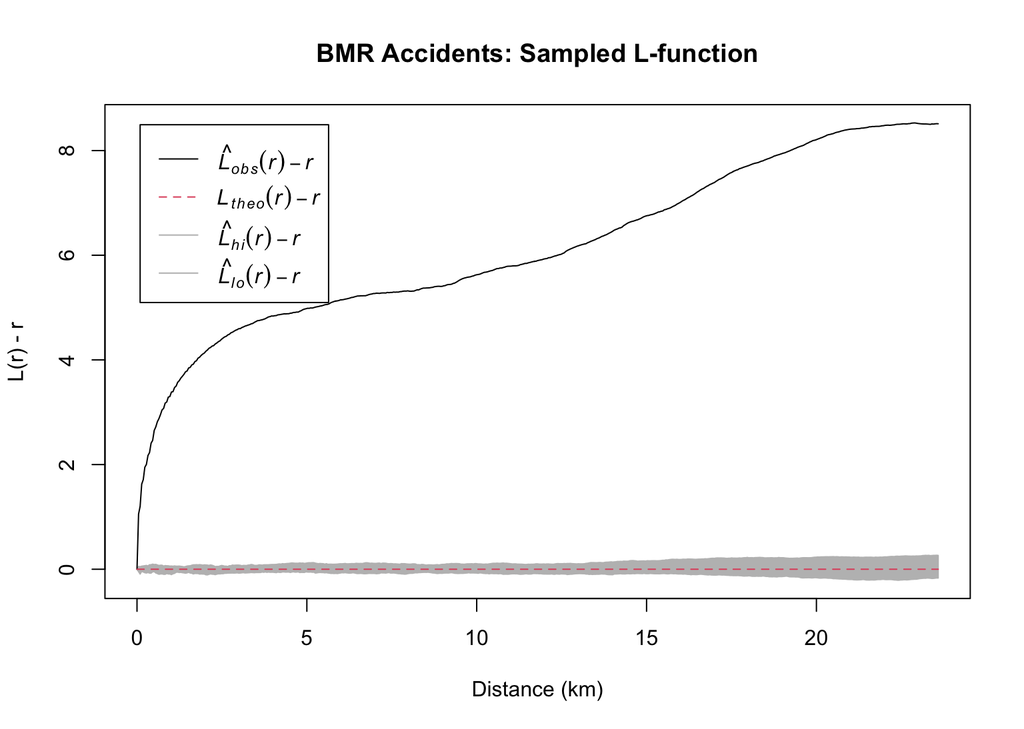

The report places the observed curve above the upper envelope across almost all positive distances shown, up to approximately **23 km**.

This supports clustering **relative to CSR** in the sample.

Uneven roads and traffic exposure could explain this departure without interaction between accidents. The envelope is not a global significance test.

## Monthly accident concentrations

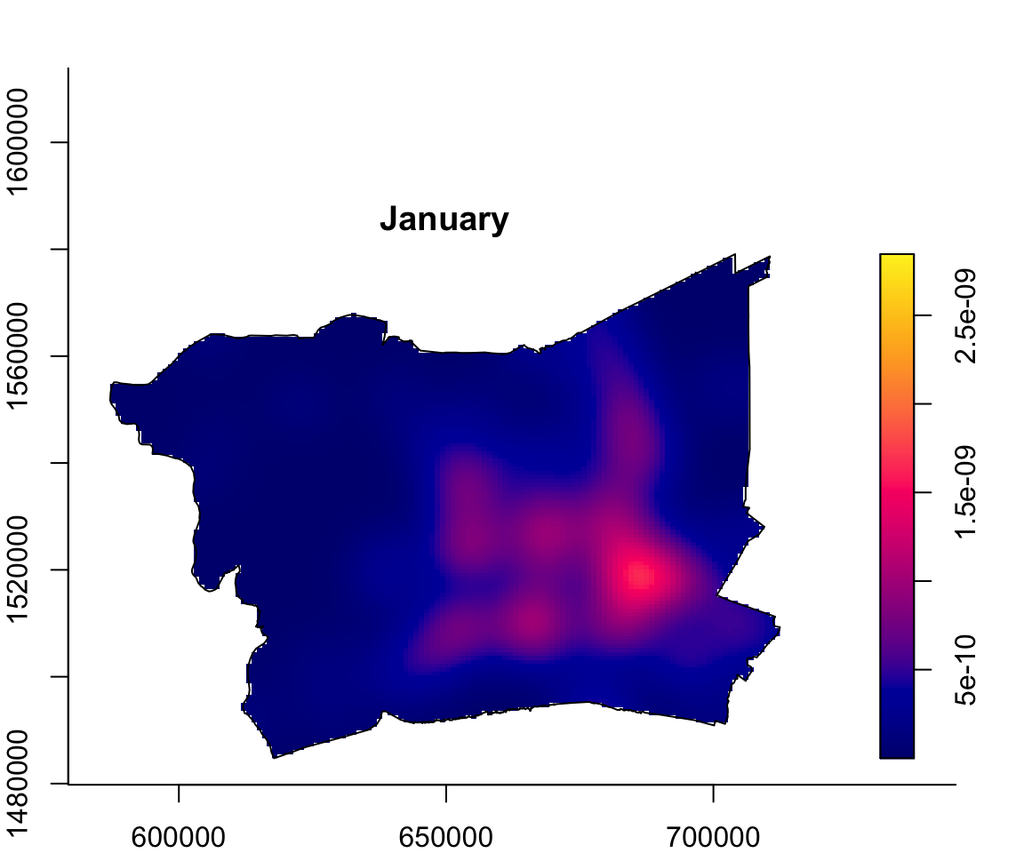

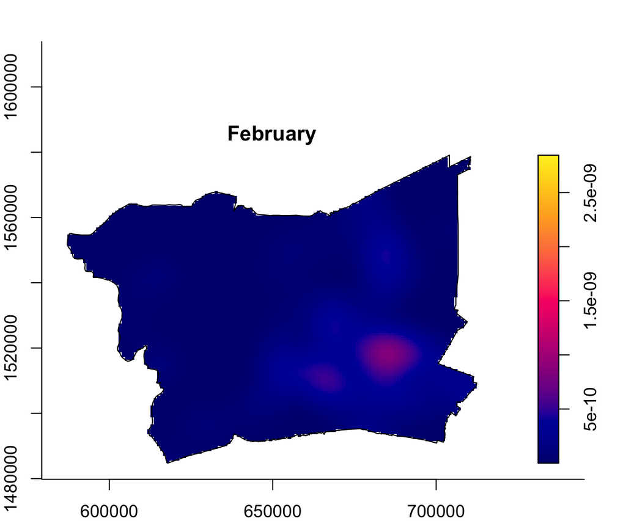

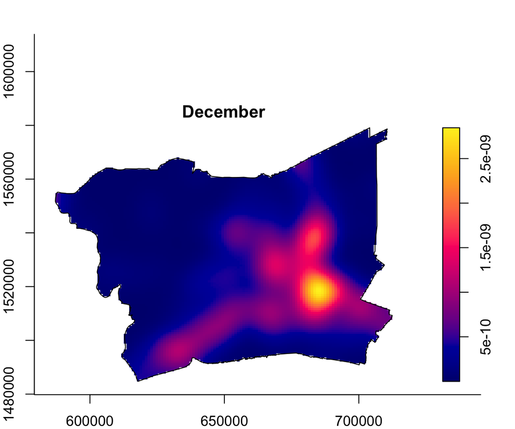

Recurring concentrations appear in central and southeastern BMR. January and December are more prominent than February, with a particularly strong southeastern concentration in December.

Reported bandwidths: 4.88 km spatial and 0.0285 months temporal. All maps use a common colour scale.

## Integrated findings

| Analytical view | Contribution |
| --- | --- |
| Annual KDE | Identifies the reported locations of higher and lower intensity |
| L-function | Shows departure from a uniform random reference across distances |
| Monthly KDE | Shows recurring locations with changing prominence between months |

The findings broadly agree that recorded accidents are unevenly distributed.

**Alternative explanations:** road layout, traffic volume and differences in reporting coverage.

## Limitations

- **KDE resolution:** the annual grid does not adequately resolve the reported Diggle bandwidth.
- **Reference model:** uniform CSR does not represent the uneven distribution of roads and traffic.
- **Sampling:** the L-function uses up to 1,000 accidents and a pointwise envelope.
- **Exposure and reporting:** recorded concentration does not establish risk per road user.
- **Time coverage:** one year cannot establish recurring seasonality. Current planning needs more recent records.

## Public-safety implications

| Potential use | Additional information needed |
| --- | --- |
| Prioritise road-safety inspections at concentrations | Road conditions, junction design, lighting and traffic management |
| Review emergency response coverage | Severity, existing facilities, travel times and service demand |
| Consider resource priorities | Traffic exposure, reporting coverage and more recent accident records |

**The findings support preliminary screening and further investigation.**

Lower recorded intensity alone does not justify reducing resources elsewhere.